# MA213 - Fall 2025

# Basic Statistics and Probability

## Pre-lab activities

- Let’s form another group of two. This time, choose a different person.
- Review of last time and questions from last time.

## Lab activities

Load some libraries

```r
library(ggplot2)
library(dplyr)
library(tidyr)
```

Load the data from `airquality.csv` and show first 5 rows to see how this data is organized.

```r
df = read.csv("airquality.csv")
head(df)
```

```
##   X Ozone Solar.R Wind Temp Month Day
## 1 1    41     190  7.4   67     5   1
## 2 2    36     118  8.0   72     5   2
## 3 3    12     149 12.6   74     5   3
## 4 4    18     313 11.5   62     5   4
## 5 5    NA      NA 14.3   56     5   5
## 6 6    28      NA 14.9   66     5   6
```

Let’s check if we have a missing value.

```r
is.na(df)
```

```
##            X Ozone Solar.R  Wind  Temp Month   Day
##   [1,] FALSE FALSE   FALSE FALSE FALSE FALSE FALSE
##   [2,] FALSE FALSE   FALSE FALSE FALSE FALSE FALSE
##   [3,] FALSE FALSE   FALSE FALSE FALSE FALSE FALSE
##   [4,] FALSE FALSE   FALSE FALSE FALSE FALSE FALSE
##   [5,] FALSE  TRUE    TRUE FALSE FALSE FALSE FALSE
##   [6,] FALSE FALSE    TRUE FALSE FALSE FALSE FALSE
##   [7,] FALSE FALSE   FALSE FALSE FALSE FALSE FALSE
##   [8,] FALSE FALSE   FALSE FALSE FALSE FALSE FALSE
##   [9,] FALSE FALSE   FALSE FALSE FALSE FALSE FALSE
##  [10,] FALSE  TRUE   FALSE FALSE FALSE FALSE FALSE
##  [11,] FALSE FALSE    TRUE FALSE FALSE FALSE FALSE
##  [12,] FALSE FALSE   FALSE FALSE FALSE FALSE FALSE
##  [13,] FALSE FALSE   FALSE FALSE FALSE FALSE FALSE
##  [14,] FALSE FALSE   FALSE FALSE FALSE FALSE FALSE
```

[output cut: 139 more lines]

Let’s save them without missing value.

```r
df_filtered <- na.omit(df)
df_filtered
```

```
##       X Ozone Solar.R Wind Temp Month Day
## 1     1    41     190  7.4   67     5   1
## 2     2    36     118  8.0   72     5   2
## 3     3    12     149 12.6   74     5   3
## 4     4    18     313 11.5   62     5   4
## 7     7    23     299  8.6   65     5   7
## 8     8    19      99 13.8   59     5   8
## 9     9     8      19 20.1   61     5   9
## 12   12    16     256  9.7   69     5  12
## 13   13    11     290  9.2   66     5  13
## 14   14    14     274 10.9   68     5  14
## 15   15    18      65 13.2   58     5  15
## 16   16    14     334 11.5   64     5  16
## 17   17    34     307 12.0   66     5  17
## 18   18     6      78 18.4   57     5  18
```

[output cut: 97 more lines]

Let’s discuss what is numerical data and what is categorical data. Also, discuss variables of interest (and possible hypothesis).

```r
head(df_filtered)
```

```
##   X Ozone Solar.R Wind Temp Month Day
## 1 1    41     190  7.4   67     5   1
## 2 2    36     118  8.0   72     5   2
## 3 3    12     149 12.6   74     5   3
## 4 4    18     313 11.5   62     5   4
## 7 7    23     299  8.6   65     5   7
## 8 8    19      99 13.8   59     5   8
```

```r
help("airquality")
```

| airquality {datasets} | R Documentation |
| --- | --- |

## New York Air Quality Measurements

### Description

Daily air quality measurements in New York, May to September 1973.

### Usage

```
airquality
```

### Format

A data frame with 153 observations on 6 variables.

| `[,1]` | `Ozone` | numeric | Ozone (ppb) |
| --- | --- | --- | --- |
| `[,2]` | `Solar.R` | numeric | Solar R (lang) |
| `[,3]` | `Wind` | numeric | Wind (mph) |
| `[,4]` | `Temp` | numeric | Temperature (degrees F) |
| `[,5]` | `Month` | numeric | Month (1–12) |
| `[,6]` | `Day` | numeric | Day of month (1–31) |

### Details

Daily readings of the following air quality values for May 1, 1973 (a Tuesday) to September 30, 1973.

- `Ozone`: Mean ozone in parts per billion from 1300 to 1500 hours at Roosevelt Island
- `Solar.R`: Solar radiation in Langleys in the frequency band 4000–7700 Angstroms from 0800 to 1200 hours at Central Park
- `Wind`: Average wind speed in miles per hour at 0700 and 1000 hours at LaGuardia Airport
- `Temp`: Maximum daily temperature in degrees Fahrenheit at LaGuardia Airport.

### Source

The data were obtained from the New York State Department of Conservation (ozone data) and the National Weather Service (meteorological data).

### References

Chambers, J. M., Cleveland, W. S., Kleiner, B. and Tukey, P. A. (1983) *Graphical Methods for Data Analysis*. Belmont, CA: Wadsworth.

Numerical Data

1. Make a scatter plot of `Ozone` and `Temp` .

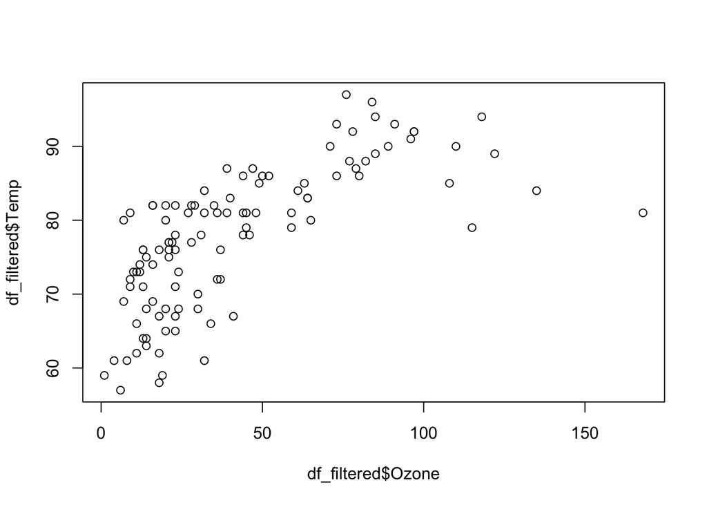

```r
plot(df_filtered$Ozone, df_filtered$Temp)
```

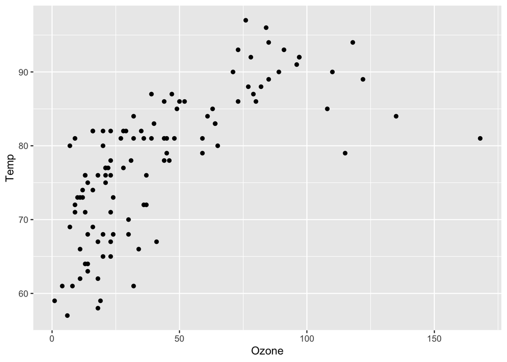

```r
# ggplot version
ggplot(data=df_filtered, mapping=aes(x=Ozone, y=Temp)) + geom_point()
```

2. Make a dot plot of `Ozone`.

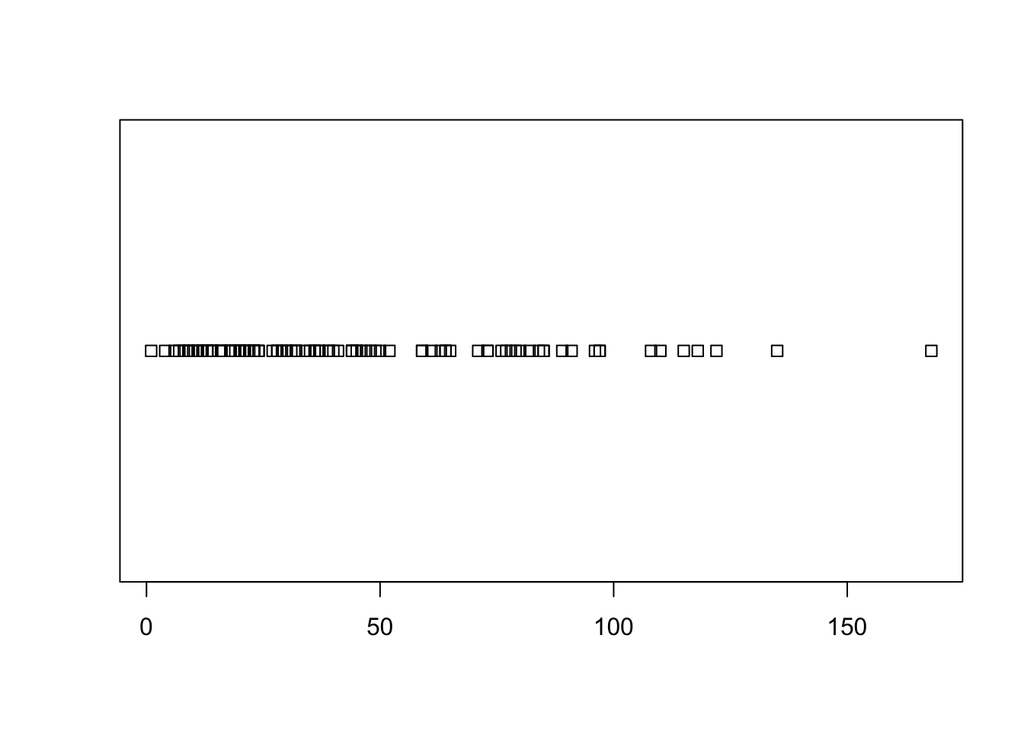

```r
stripchart(df_filtered$Ozone)
```

3. Make a stacked dot plot of `Ozone` .

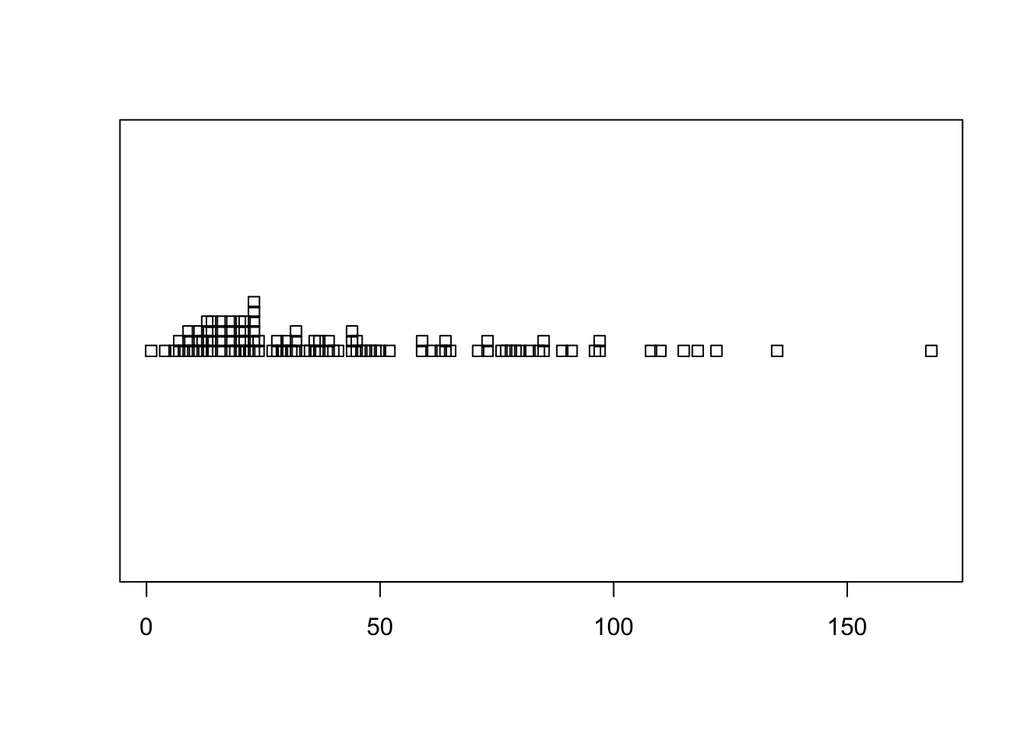

```r
stripchart(df_filtered$Ozone, method = "stack")
```

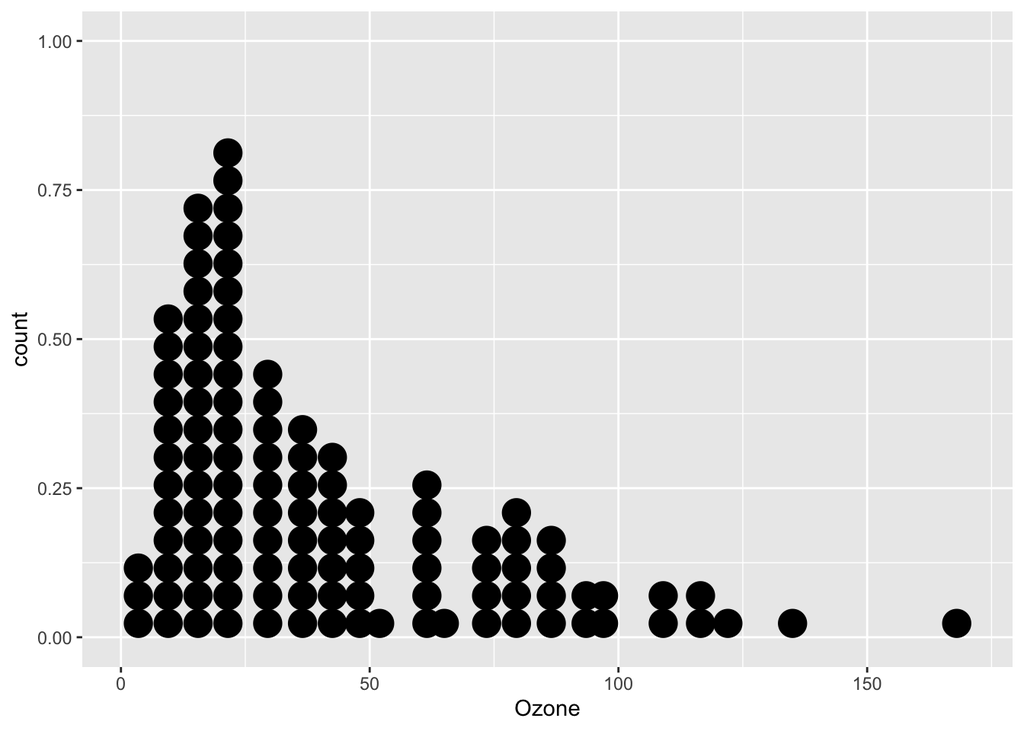

```r
# ggplot version

ggplot(data=df_filtered, mapping=aes(Ozone)) + geom_dotplot()
```

4. Show histogram of `Ozone` .

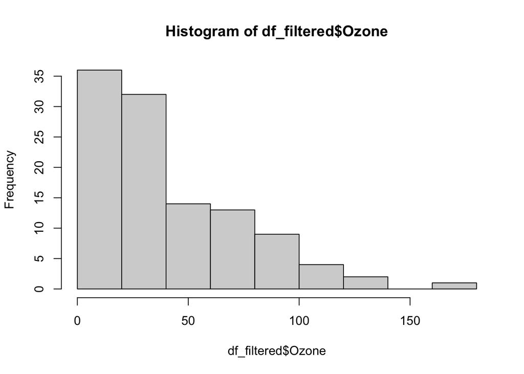

```r
hist(df_filtered$Ozone)
```

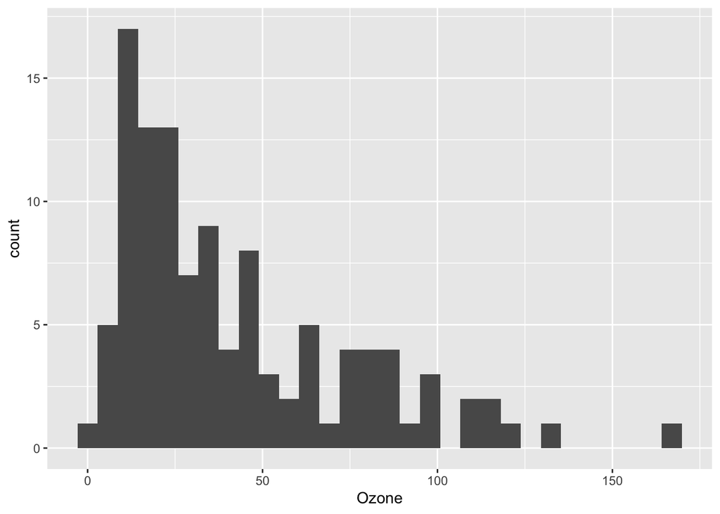

```r
# ggplot version

ggplot(data=df_filtered, mapping=aes(Ozone)) + geom_histogram()
```

4. Show histogram of `Ozone` with different bins/breaks to show more information.

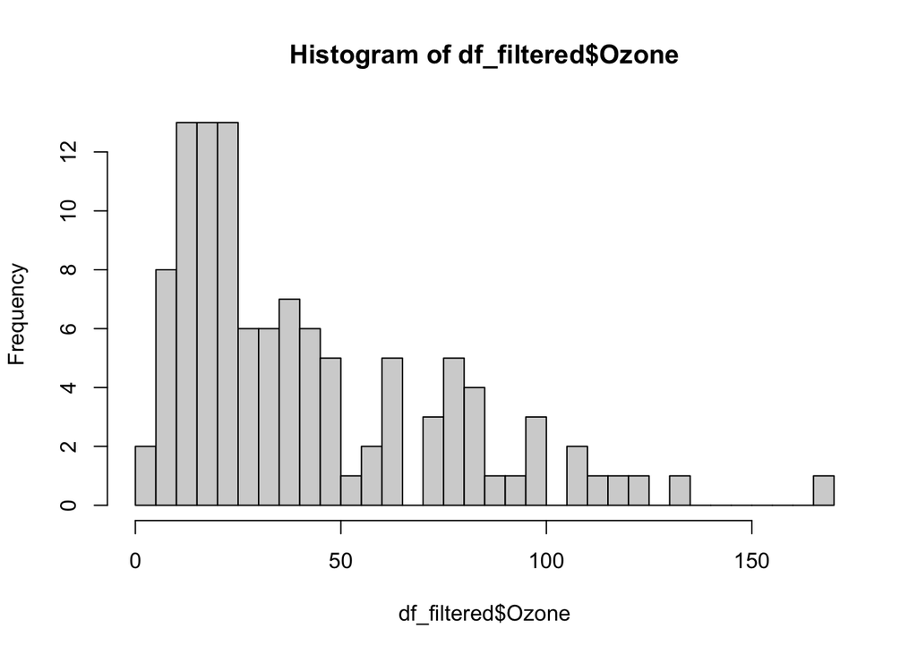

```r
hist(df_filtered$Ozone, breaks=30)
```

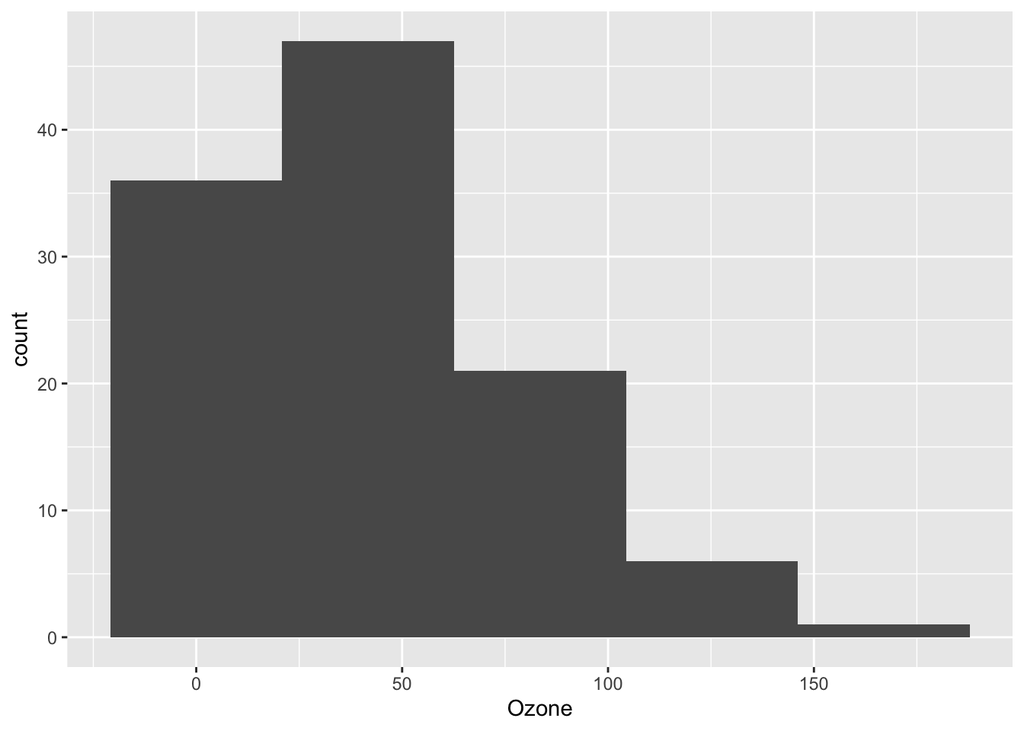

```r
# ggplot version

ggplot(data=df_filtered, mapping=aes(Ozone)) + geom_histogram(bins = 5)
```

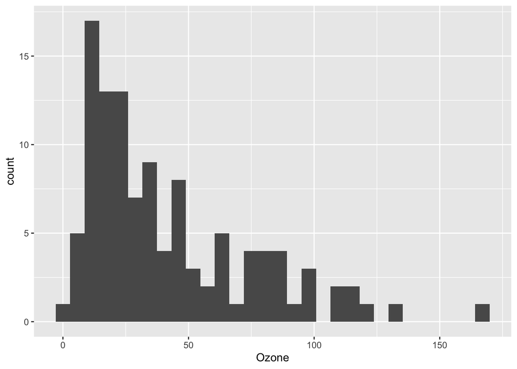

```r
ggplot(data=df_filtered, mapping=aes(Ozone)) + geom_histogram(bins = 30)
```

## Categorical Data

We are going to see the famous `Titanic` dataset.

Let’s load the data.

```r
# loading from csv file
df <- read.csv("titanic.csv")
head(df)
```

```
##   PassengerId Survived Pclass
## 1           1        0      3
## 2           2        1      1
## 3           3        1      3
## 4           4        1      1
## 5           5        0      3
## 6           6        0      3
##                                                  Name    Sex Age SibSp Parch
## 1                             Braund, Mr. Owen Harris   male  22     1     0
## 2 Cumings, Mrs. John Bradley (Florence Briggs Thayer) female  38     1     0
## 3                              Heikkinen, Miss. Laina female  26     0     0
## 4        Futrelle, Mrs. Jacques Heath (Lily May Peel) female  35     1     0
## 5                            Allen, Mr. William Henry   male  35     0     0
## 6                                    Moran, Mr. James   male  NA     0     0
##             Ticket    Fare Cabin Embarked
## 1        A/5 21171  7.2500              S
## 2         PC 17599 71.2833   C85        C
## 3 STON/O2. 3101282  7.9250              S
## 4           113803 53.1000  C123        S
## 5           373450  8.0500              S
## 6           330877  8.4583              Q
```

```r
# maybe we can also show built in Titanic data
# but this data is already table df
```

Which one is numerical variable and which one is categorical variable?

How do we know? Let’s discuss about them.

```r
summary(df)
```

```
##   PassengerId       Survived          Pclass          Name
##  Min.   :  1.0   Min.   :0.0000   Min.   :1.000   Length:891
##  1st Qu.:223.5   1st Qu.:0.0000   1st Qu.:2.000   Class :character
##  Median :446.0   Median :0.0000   Median :3.000   Mode  :character
##  Mean   :446.0   Mean   :0.3838   Mean   :2.309
##  3rd Qu.:668.5   3rd Qu.:1.0000   3rd Qu.:3.000
##  Max.   :891.0   Max.   :1.0000   Max.   :3.000
##
##      Sex                 Age            SibSp           Parch
##  Length:891         Min.   : 0.42   Min.   :0.000   Min.   :0.0000
##  Class :character   1st Qu.:20.12   1st Qu.:0.000   1st Qu.:0.0000
##  Mode  :character   Median :28.00   Median :0.000   Median :0.0000
##                     Mean   :29.70   Mean   :0.523   Mean   :0.3816
##                     3rd Qu.:38.00   3rd Qu.:1.000   3rd Qu.:0.0000
##                     Max.   :80.00   Max.   :8.000   Max.   :6.0000
##                     NA's   :177
##     Ticket               Fare           Cabin             Embarked
##  Length:891         Min.   :  0.00   Length:891         Length:891
##  Class :character   1st Qu.:  7.91   Class :character   Class :character
##  Mode  :character   Median : 14.45   Mode  :character   Mode  :character
##                     Mean   : 32.20
##                     3rd Qu.: 31.00
##                     Max.   :512.33
##
```

1. Show the contingency table for `Pclass` vs `Survived` .

```r
df2 <- df[,2:3]
table_data <- table(df2)
print(table_data)
```

```
##         Pclass
## Survived   1   2   3
##        0  80  97 372
##        1 136  87 119
```

```r
# tidyr version

table_data <- df %>%
  count(Pclass, Survived) %>%
  tidyr::spread(key = Pclass, value = n, fill = 0)
table_data
```

```
##   Survived   1  2   3
## 1        0  80 97 372
## 2        1 136 87 119
```

```r
table_data <- df %>%
  count(Survived, Pclass) %>%
  tidyr::pivot_wider(names_from = Pclass, values_from = n, values_fill = list(n = 0))

table_data
```

```
## # A tibble: 2 × 4
##   Survived   `1`   `2`   `3`
##      <int> <int> <int> <int>
## 1        0    80    97   372
## 2        1   136    87   119
```

2.Show Bar plot of `Survived`.

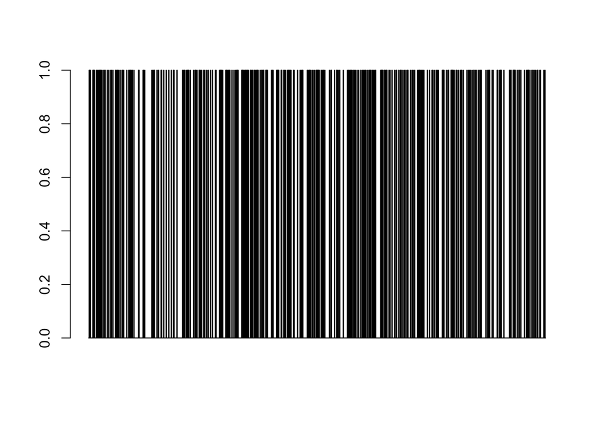

```r
barplot(df2$Survived) #try this !! this won't work
```

```r
# but try
Survived_table <- table(df2$Survived)
Survived_table
```

```
##
##   0   1
## 549 342
```

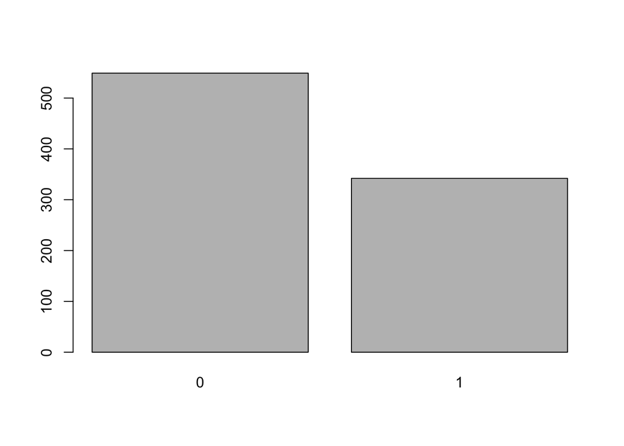

```r
barplot(Survived_table)
```

```r
# ggplot + dplyr version

new_df <- df %>% count(Survived)

ggplot(new_df, aes(x = factor(Survived), y=n)) +
  geom_col()
```

[output not shown]

```r
# You can even combine dplyr + ggplot codes
df %>% count(Survived) %>%
  ggplot(aes(x=factor(Survived), y=n)) +
  geom_col()
```

[output not shown]

```r
# You can assign this plot to an object
My_bar_plot <- df %>% count(Survived) %>%
  ggplot(aes(x=factor(Survived), y=n)) +
  geom_col()

My_bar_plot
```

[output not shown]

3. Show the pie chart of `Pclass`.

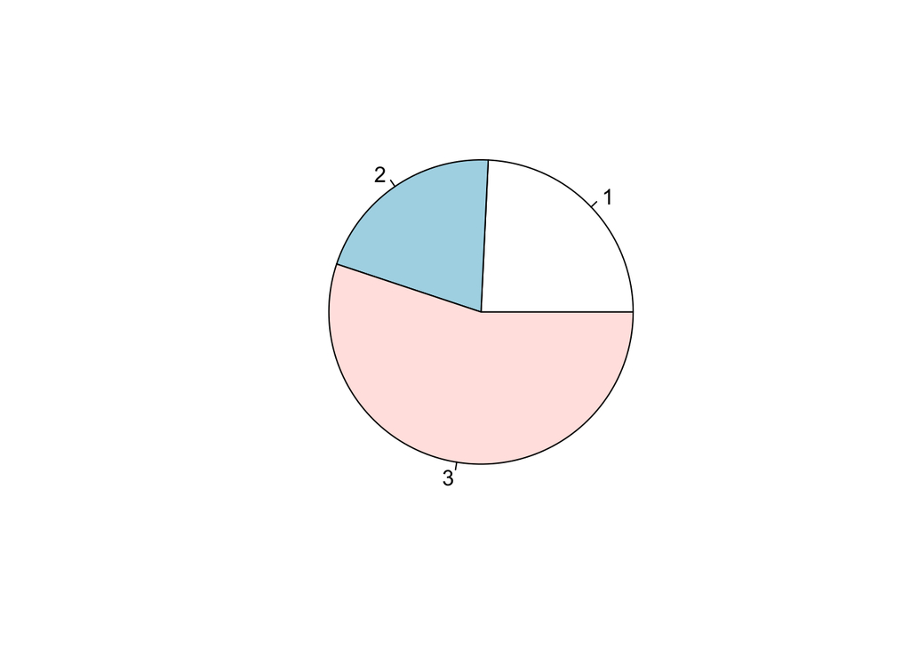

```r
Pclass_table <- table(df$Pclass)
pie(Pclass_table)
```

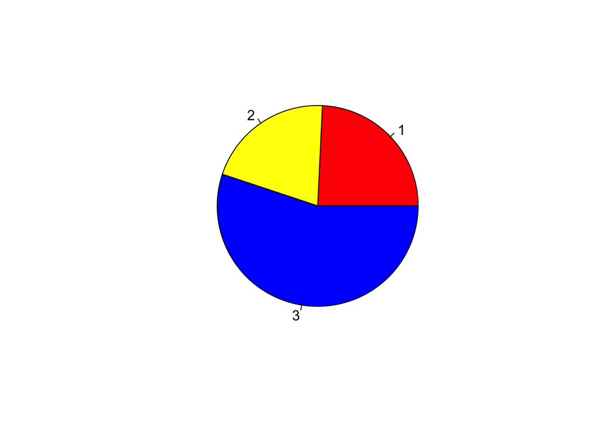

```r
pie(Pclass_table, col = c("red", "yellow", "blue"))
```

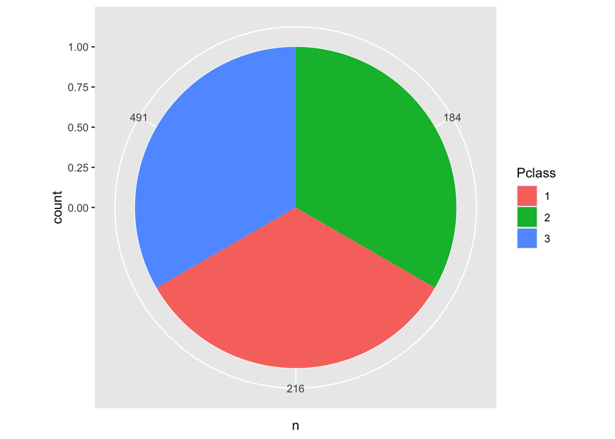

```r
# dplyr + ggplot

Myplot <- df %>% count(Pclass) %>%
  mutate(Pclass = factor(Pclass), n = factor(n)) %>%
  ggplot(aes(x=n, fill=Pclass)) + geom_bar(width = 1) + coord_polar()

Myplot
```

4. We are also interested in the average age of each class. Show the bar plot of average age per each class.

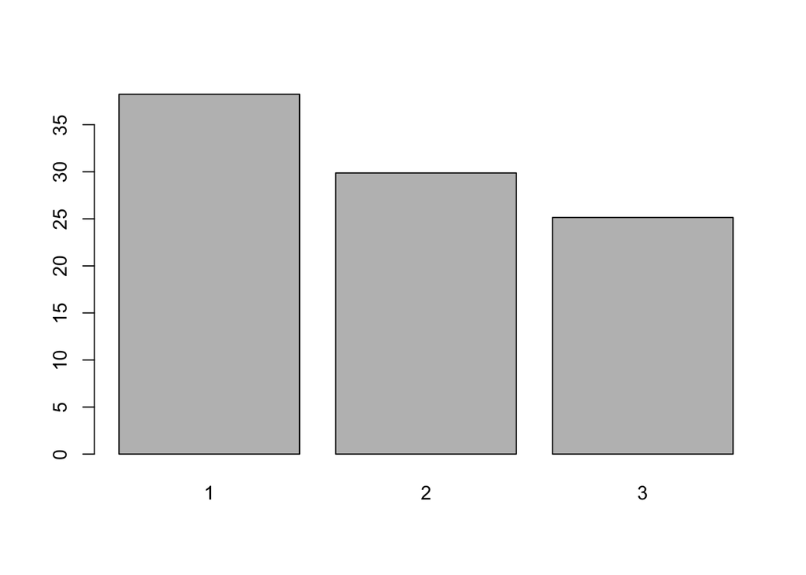

   ```r
   avg_age <- aggregate(Age ~ Pclass, data = df, FUN = mean, na.rm = TRUE)

   barplot(avg_age$Age, names.arg = avg_age$Pclass)
   ```

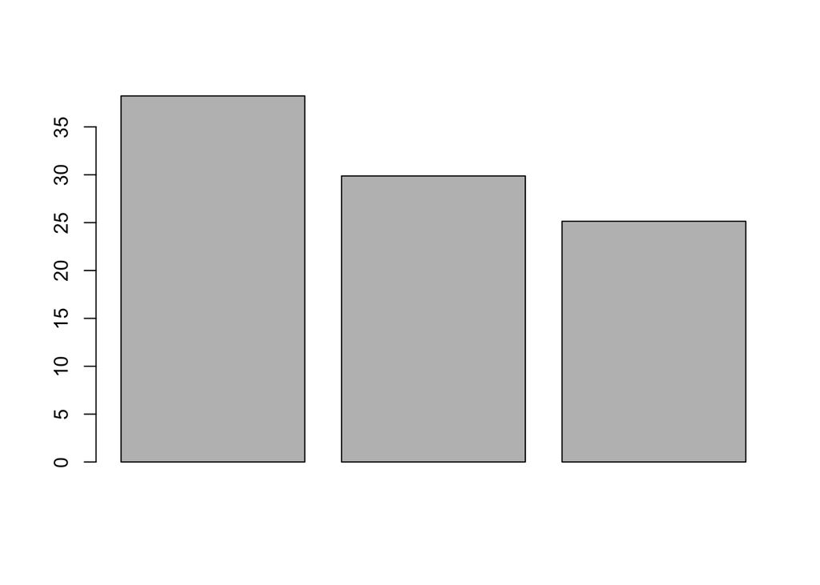

   ```r
   # or
   # dplyr version
   avg_age <- df %>%
     group_by(Pclass) %>%
     summarise(Age = mean(Age, na.rm=T))


   barplot(avg_age$Age)
   ```

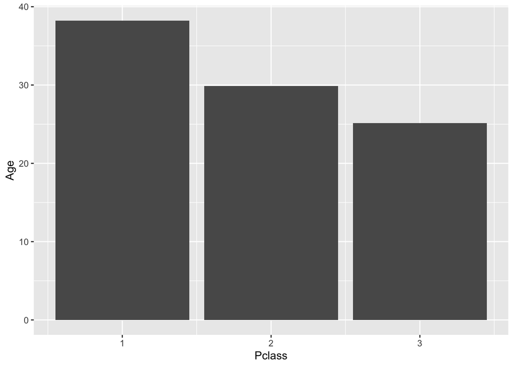

   ```r
   # ggplot version
   myplot <- ggplot(data = avg_age, aes(Pclass, Age)) + geom_col()

   myplot
   ```

### Post-lab activities

Please name your submission as `lab2.R`

We are going to also analyze this New York Air Quality Measurements data again. This time, we are going to see how Solar radiation is behaving with Temperature.

0. load the `airquality.csv` file and assign it to `my_df` object.
1. Show the scatter plot of Solar radiation and Temperature.
2. Show average Solar radiation in each month. Use bar plot.

   2.1) Assign average Solar radiation into object `solar_radiation_avg` .

   2.2) Show the bar plot of average Solar radiation per each month.

Back to Titanic data.

0. Show the pie chart of `sex` in `titanic` data.

   3.1) Load `titanic.csv` file and assign it to `my_df2` object.

   3.2) Show the pie chart of `sex` .